# Getting started with McBias

Ash Breidenbach

2025-08-19

The library McBias simulates and analyzes datasets using a directed acyclic graph object (DAG object) that the user sets. This allows the user to create a dataset where all effect sizes and distributions are known. By analyzing the dataset in a biased way, the user can quantify how much the biased effect size drifts from the originally set effect size.

*Note: if only bernoulli or gaussian distributions are used to set nodes then the user can use the accompanying RShiny app which will write the lines of code below. In this case, skip to step 3*.

**You can access RShiny app url to write the code for steps 1 and 2 [here](https://mcbias.shinyapps.io/rshiny_bias/).**

## Step 1 - Create a Directed Acyclic Graph (DAG)

To begin we must set our DAG object. Each node in the DAG will correspond to that variable’s column in the simulated datasets. Each edge (arrow) sets which nodes influence others. Our DAG object must not have bidirectional arrows or cycles. Each node in the DAG will correspond to a different column in the dataset.

```r
#We will start with a simple DAG where node A affects node B and C, and node B and C affect Node D
#We write which variables cause others like this: 'effect|cause1*cause2*cause_n' or like this 'effect|cause1 + effect|cause2 + effect|cause_n'.
#Start each Hydenetwork argurment with ~

my_dag = HydeNetwork(~B|A + C|A + D|B*C)
```

You can plot the following DAG with the Rgraphviz library if desired

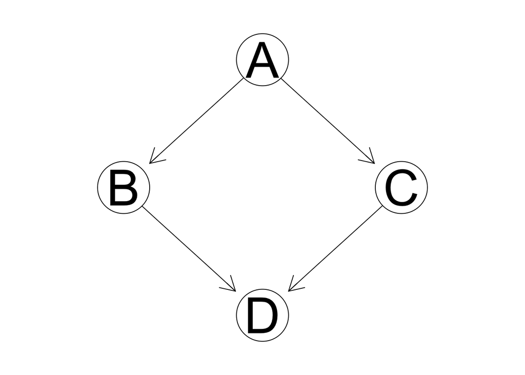

```r
#my_dag$dag gives adjacency matrix for plotting DAG
my_graph<-new(Class="graphAM", adjMat=my_dag$dag, edgemode="directed")
plot(my_graph)
```

## Step 2 - Add distributions to your DAG

Once we’ve established a DAG, we must set each node’s distribution and each edge’s effect size. We can see all our node’s distributions are currently unspecified.

```r
writeNetworkModel(my_dag, pretty = TRUE)
```

```
## model{
##    B ~ dnorm(Unspecified, Unspecified)
##    A ~ dnorm(Unspecified, Unspecified)
##    C ~ dnorm(Unspecified, Unspecified)
##    D ~ dnorm(Unspecified, Unspecified)
## }
```

We’ll set the distributions as follows:

- Node **A** is binary, and will have a **Bernoulli** distribution with a probability (p) of **0.5**
- Node **B** is continuous and will have a **Gaussian** distribution with a mean of **0** and an sd of **1**
- Node **C** is binary, and will have a **Bernoulli** distribution with a probability (p) of **0.9**
- Node **D** is binary, and will have a **Bernoulli** distribution with a probability (p) of **0.25**

Each interaction between nodes must have a set effect size. For this example we’ll set those as follows:

- **A** -> **B** is 0.2
- **A** -> **C** is 0.8
- **B** -> **D** is 0.05
- **C** -> **D** is 1.2

Setting effect sizes requires writing generalized linear models (GLMs) within the distribution. Below is example code that discloses how to write them. Our RShiny app can write the GLM code for you as long as all nodes distributions are Bernoulli or Gaussian.

```r
#we can set the distributions of each node with the setNode() command from Hydenet

#Node A is a binary variable, so its nodeType is set to "dbern" for Bernoulli. Node A is not affected by any other nodes, and thus is an independent variable. Its probability is directly set.

my_dag = setNode(my_dag, A, nodeType = "dbern", prob = 0.5)


#Node B is gaussian, so it's nodeType is set to "dnorm". It is dependent on node A so its mean changes depending on if a 1 or 0 is chosen for node A during the simulation. Since the effect size of A -> B is 0.2, we multiply that 1 or 0 by 0.2. Thus, to set node B's overall mean we take the mean, 0, and subtract it by the product of node A's probability and effect size (0 - 0.2 * 0.5).

#Since Hydenet is a wrapper for rjags, non-numeric values must be in a string, hence the paste0() function is needed.

my_dag = setNode(my_dag, B, nodeType = "dnorm", mu = paste0(0.2," * A + ",0 - 0.2*0.5), tau = 1)


#Node C is a dependent binary variable, and thus must be wrapped in an "ilogit(" ")" command from rjags. This ensures the probability stays between 0 and 1

#Node C's overall probability is set with the set_p() function where the first argument is the overall probability (0.9) and the second argument is the product of node A's probability and effect size (0.8*0.5 for node C)

my_dag = setNode(my_dag, C, nodeType = "dbern", prob = paste0("ilogit(",0.8," * A + ",set_p(0.9, 0.8*0.5),")"))


#Node D is also a dependent binary variable, so it is set similarly to node C. Note that node B's product of its effect size and mean is added to the product of node C's effect size and probability. I wrote out node B's product in set_p() for illustrative effect, even though in this case it is unnecessary because node B's product = 0

my_dag = setNode(my_dag, D, nodeType = "dbern", prob = paste0("ilogit(",0.05," * B + ", 1.2," * C + ",set_p(0.25, 1.2 * 0.9 + 0.05 * 0 ),")"))

#We can now see that all our nodes in our DAG object have a set distribution
writeNetworkModel(my_dag, pretty = TRUE)
```

```
## model{
##    B ~ dnorm(0.2 * A + -0.1, 1)
##    A ~ dbern(0.5)
##    C ~ dbern(ilogit(0.8 * A + 1.79722457733622))
##    D ~ dbern(ilogit(0.05 * B + 1.2 * C + -2.17861228866811))
## }
```

## Step 3 - create simulations from the DAG

Now that a DAG object is set, simulations can began. create_data() allows a single dataset to be generated. Binary nodes are portrayed as 0 or 1 integers

```r
sim_df = create_data(my_dag, 10000)
head(create_data(my_dag, 10000))
```

| A | B | C | D |
| --- | --- | --- | --- |
| 1 | -0.6889359 | 1 | 0 |
| 1 | -0.3741993 | 1 | 0 |
| 0 | 0.3441454 | 1 | 1 |
| 0 | 0.7089610 | 1 | 0 |
| 1 | 1.2240422 | 1 | 0 |
| 0 | -0.8319860 | 1 | 0 |

We can check this created dataset to make sure our set distributions were set the way we expected.

*Note: Bernoulli nodes that are dependent on Gaussian nodes can sometimes skew positively or negatively as their probability approaches 0 or 1 respectively. In this case, if the probability is set near 0, the generated dataset’s prevalence for the node can skew higher. If the probability is near 1 the simulated dataset’s prevalence can skew lower.*

```r
sum_df = data.frame("Node A prevalence" = sum(sim_df$A)/length(sim_df$A),
                    "Node B mean" = round(mean(sim_df$B), 4),
                    "Node C prevalence" = sum(sim_df$C)/length(sim_df$C),
                    "Node D prevalence" = sum(sim_df$D)/length(sim_df$D))
sum_df
```

| Node.A.prevalence | Node.B.mean | Node.C.prevalence | Node.D.prevalence |
| --- | --- | --- | --- |
| 0.4978 | 0.0036 | 0.8961 | 0.2537 |

This summary of one simulated dataset reflects the distributions we set.

## Step 4 - Analyze the simulations

Now that we have a working DAG object (my_dag) we can start to analyze it in various ways. varied_runs() generates multiple datasets and analyzes them as specified. It returns a list with 11 elements, with each element corresponding to a different summary statistic as shown below:

1. **ratio** Odds/risk ratio if applicable (will return NAs if not)
2. **calculated_ate** estimated effect size/ estimated average treatment effect (ATE)
3. **lower_int** lower 95% confidence interval
4. **upper_int** upper 95% confidence interval
5. **p_values** p_value
6. **exp_prevalence** exposure prevalence, if applicable (will return NAs if not)
7. **out_prevalence** outcome prevalence, is applicable (will return NAs if not)
8. **sample_population** sample population
   - If matching methods are used it will report the matched sample population (i.e. if there are 10 cases in a dataset of 100, and 1:1 matching is used, the sample population becomes 20, as unmatched cases are thrown).
   - if selection bias is simulated, n will be the number of samples that entered the analyzed dataset
9. **set_ate** The effect size set in the original model (considered as the true effect size)
10. **over_r** the set overdiagnosis rate, if set (will return 0s if not)
11. **under_r** the set underdiagnosis rate, if set (will return 0s if not)

Varied runs can analyze the dataset with various methods as set by the user. if this is the case, it will return those 11 summary statistics for method used. The methods run are bulleted below:

**If the outcome is Bernoulli**: “logistic_regression* is run.”ps_weighting” or propensity score weighting is also run if there are covariates.

**If the outcome is Gaussian**: “linear_regression” is run. “ps_weighting” or propensity score weighting is also run if there are covariates.

The user also has the option of installing matchit and running matchit analyses, these are included with the other methods if set. Only greedy matching methods are available at this time.

We’ll fill in the arguments below:

- **runs** = 500
  - 500 datasets will be created and analyzed
- **dag** = my_dag
  - must be a DAG object
- **exposure** = “B”
- **outcome** = “C”
- **covariates** = “A”
  - A will be adjusted on
- **n** = 100000
  - each dataset will have 100000 samples

```r
ideal = varied_runs(500, my_dag, "B", "C", "A", n = 100000)
```

The run results are saved as a list of 11. We can splice the results to look at any summary statistic we’re interested in.

```r
head(ideal$calculated_ate)
```

```
##      logistic_regression  ps_weighting
## [1,]        0.0053150994  0.0040323404
## [2,]        0.0133160750  0.0133988747
## [3,]        0.0022688862  0.0012347857
## [4,]        0.0207999635  0.0195176350
## [5,]        0.0001814446 -0.0005297584
## [6,]        0.0024373555  0.0027104388
```

We can visually compare how the methods compared to each other by using ci_ridges().

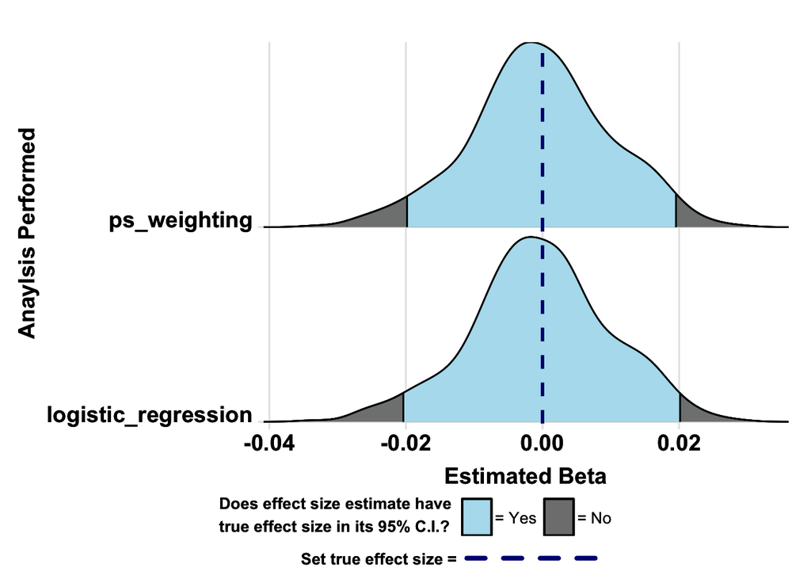

```r
ci_ridges(ideal)
```

We can use beta_summary() to get more details on the simulation we just ran.

beta_summary() gives the following outputs:

- **Bias** and its standard error. Bias is the difference between the calculated effect size and the true effect size
- **Coverage** and its standard error. Coverage gives the percentage of calculated effect sizes that contained the true effect size in their 95% confidence intervals. The aim is to have coverage be around 95%
- **Rejection rate** and its standard error. Rejection rate is the percentage of times the null hypothesis was rejected as an alpha value. The alpha value can be set in the second argument and defaults to 0.05.
- **Mean B estimate** gives the mean of all the calculated effect sizes.
- **B estimate std dev** gives the standard deviation of all the calculated effect sizes. Provides insight into changes in precision

```r
ideal_sim_summary = round(beta_summary(ideal, a = 0.05), 4)
ideal_sim_summary
```

|  | bias | bias_se | coverage | coverage_se | rejection_rate | rejection_rate_se | mean_b_estimate | b_estimate_std_dev |
| --- | --- | --- | --- | --- | --- | --- | --- | --- |
| logistic_regression | -3e-04 | 5e-04 | 95.0 | 0.9747 | 5.0 | 0.9747 | -3e-04 | 0.0102 |
| ps_weighting | -4e-04 | 5e-04 | 94.8 | 0.9929 | 5.2 | 0.9929 | -4e-04 | 0.0102 |

So here we can see that when node **A** is adjusted we get a mean effect size estimate near 0 between **B** and **C** over the 500 simulated datasets. Since **B** has no set arc on **C**, the true effect size is set to 0.

**ideal** was the proper analysis. The collider **D** was not adjusted, and the confounder **A** was. The summary of ideal’s simulation reflects this. The difference between the mean of the calculated effect sizes and the true effect size is near 0. We also see that the rejection rate approximately equals the alpha value, which we set at 0.05. Coverage also approximately equals 95%. Overall this means that when everything is adjusted properly one gets results with very little bias, and the true effect size approximately equals the calculated effect size.

What if the ideal couldn’t be obtained? Suppose we didn’t know to adjust for **A** or were given a dataset that was stratified on **D**? We can simulate the following scenarios to estimate how much bias different scenarios like these would cause.

- **naive**: the dataset isn’t adjusted in anyway. Here we expect to see confounder bias from node **A**
- **selection_bias**: we assume that node **D** represents entry into the study. We will cut samples from the dataset where **D** = 0 and then analyze them.
- **adjust_all**: we adjust on both **A** and **D**

```r
naive = varied_runs(500, my_dag, "B", "C", n = 100000)
selection_bias = varied_runs(500, my_dag, "B", "C", sb = "D", n = 400000) #n is larger here. D has a prevalence of 0.25 and only samples with D will make it to the cut dataset that is analyzed. If we want n to be similar to the runs we are comparing it too, we'll have to multiply n * 1/p

adjust_all = varied_runs(500, my_dag, "B", "C", c("A", "D"), n = 100000)
```

## Step 5- compare multiple simulations to each other

To compare these datasets we can use reparse_runs(). You can use this to compare how different scenarios did. To use this, the following requirements must be met.

- All scenarios must have the same number of iterations for varied_runs, in this example all scenarios have 500 iterations
- The DAG object, exposure, and outcome must remain the same across all scenarios

For this example, we’ll compare the “logistic regression” method results of each scenario, so method = “logistic_regression”.

```r
run_list = list(ideal, naive, selection_bias, adjust_all)
combined_log_r = reparse_runs(run_list, method = "logistic_regression", list_names = c("ideal", "naive", "selection bias", "adjust all"))
```

You can see in combined_log_r that the methods have been switched out for the different scenarios, with each run’s logistic_regression results used.

```r
head(combined_log_r$calculated_ate)
```

```
##          ideal   adjust all      naive selection bias
## 1 0.0053150994 -0.006674109 0.04624580    0.013512730
## 2 0.0133160750  0.003526612 0.05791554    0.054267252
## 3 0.0022688862 -0.001944717 0.04203562    0.009546288
## 4 0.0207999635 -0.008696753 0.04003913    0.034649467
## 5 0.0001814446 -0.029199592 0.05344916    0.047162324
## 6 0.0024373555 -0.022278445 0.03062524    0.040237044
```

as we did before, you can use ci_ridges for quick comparisons

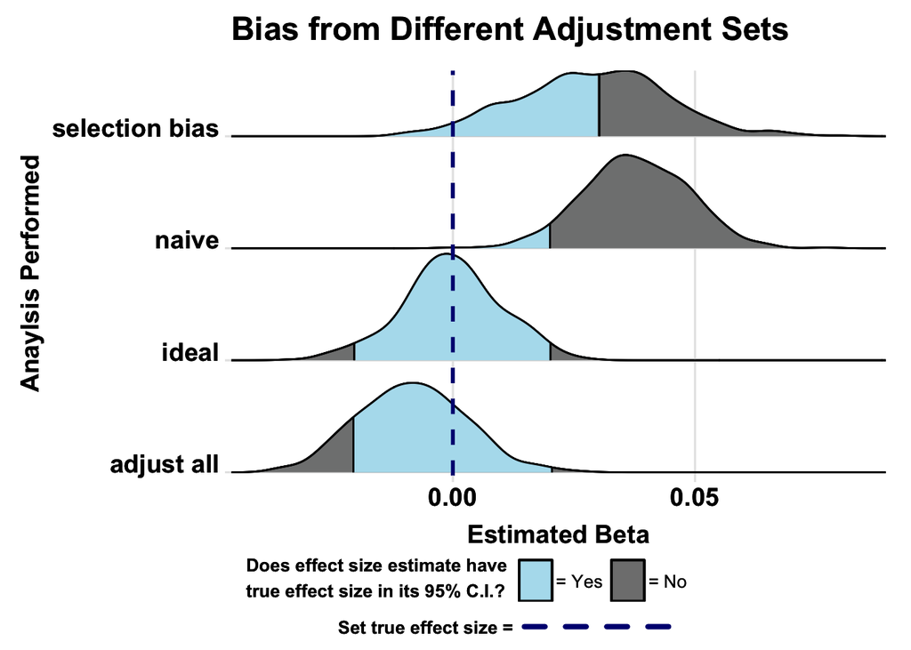

```r
ci_ridges(combined_log_r, title = "Bias from Different Adjustment Sets")
```

As we can see, the other non-ideal scenarios show signs of bias.

```r
combined_summary = round(beta_summary(combined_log_r), 4)
combined_summary
```

|  | bias | bias_se | coverage | coverage_se | rejection_rate | rejection_rate_se | mean_b_estimate | b_estimate_std_dev |
| --- | --- | --- | --- | --- | --- | --- | --- | --- |
| ideal | -0.0003 | 5e-04 | 95.0 | 0.9747 | 5.0 | 0.9747 | -0.0003 | 0.0102 |
| adjust all | -0.0084 | 5e-04 | 85.4 | 1.5791 | 14.6 | 1.5791 | -0.0084 | 0.0110 |
| naive | 0.0378 | 5e-04 | 4.6 | 0.9368 | 95.4 | 0.9368 | 0.0378 | 0.0107 |
| selection bias | 0.0289 | 7e-04 | 52.6 | 2.2330 | 47.4 | 2.2330 | 0.0289 | 0.0154 |

We can verify here that significant bias is present in all non-ideal scenarios. We can see that the false positive rate for all non-ideal scenarios is higher because the bias caused the mean calculated effect estimate to shift away from 0. The non-ideal scenario with the next lowest bias, adjust_all, still has about 3 times the likelihood of rejecting the null that the ideal scenario does.

## Running Alternative Methods

### Alternate regression methods

If needed, specific types of regression can be set with the family argument.

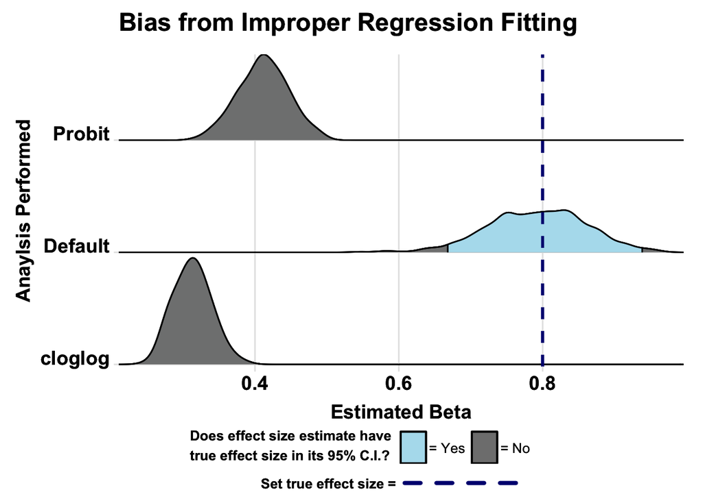

|  | bias | bias_se | coverage | coverage_se | rejection_rate | rejection_rate_se | mean_b_estimate | b_estimate_std_dev |
| --- | --- | --- | --- | --- | --- | --- | --- | --- |
| Default | -0.0079 | 0.0031 | 95.4 | 0.9368 | 100 | 0 | 0.7921 | 0.0684 |
| Probit | -0.3884 | 0.0016 | 0.0 | 0.0000 | 100 | 0 | 0.4116 | 0.0348 |
| cloglog | -0.4871 | 0.0012 | 0.0 | 0.0000 | 100 | 0 | 0.3129 | 0.0258 |

```r
default_run = varied_runs(500, my_dag, "A","C", n = 10000, family = quasibinomial(link = "logit")) #default
probit_run = varied_runs(500, my_dag,  "A","C",  n = 10000, family = quasibinomial(link = "probit"))
cloglog_run = varied_runs(500, my_dag,  "A","C", n = 10000, family = quasibinomial(link = "cloglog"))

combined_regression = reparse_runs(list(default_run, probit_run, cloglog_run), method = "regression", list_names = c("Default",  "Probit", "cloglog"))

ci_ridges(combined_regression, title = "Bias from Improper Regression Fitting")
beta_summary(combined_regression)
```

McBias will default to a logistic regression for a binary outcome and a linear regression for a continuous outcome. Since we set our GLM for outcome node C with log odds ratio coefficients and the logit linker function, the default logistic regression converges on the effect size estimate properly. Probit and cloglog do not fit properly to our simulated data so bias arises from an improper method being used.

Depending on the distributions you set for the outcome, a different regression type may needed (ex. family = “poisson” for an outcome with a poisson distribution). Certain regression types are incapable of analyzing certain outcome distributions. For example, trying to measure a gaussian outcome (like node B) with family = quasibinomial(link = “logit”) results in an error. The default regression is always the proper regression for any GLMs created by RShiny.

### Matching methods through MatchIt

Matching methods are also available if the MatchIt library is installed. Matching methods are more computationally demanding than regression, especially with higher sample sizes (typically n > 10000). Keep this in mind when when setting the number. Because of this, only nearest matching methods are available, though the user can set any distance method MatchIt offers with the match_methods argument. If the exposure is continuous data, the top 25% quartile will be marked as cases and the rest controls. Any unmatched data will be thrown from the set, the reduced sample size will be reported under the sample_population element in the output list

```r
matching_run1 = varied_runs(500, my_dag, "B", "C", "A",  n = 10000, match_methods = c("Mahalanobis"), ratio =1)

head(matching_run1$sample_population,3)
ci_ridges(matching_run1)
beta_summary(matching_run1)
```

| regression | ps_weighting | Mahalanobis |
| --- | --- | --- |
| 10000 | 10000 | 5000 |
| 10000 | 10000 | 5000 |
| 10000 | 10000 | 5000 |

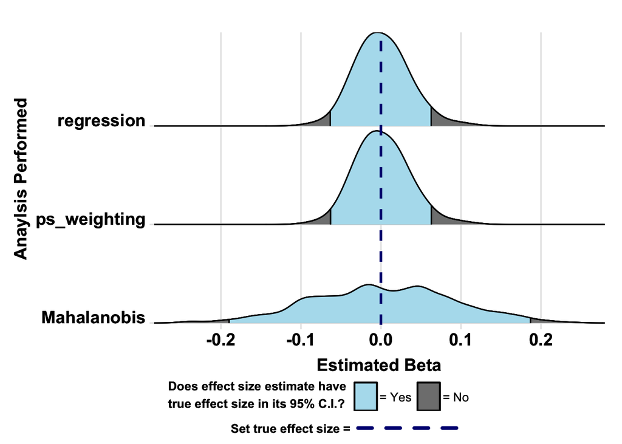

|  | bias | bias_se | coverage | coverage_se | rejection_rate | rejection_rate_se | mean_b_estimate | b_estimate_std_dev |
| --- | --- | --- | --- | --- | --- | --- | --- | --- |
| regression | 0.0014 | 0.0015 | 94.4 | 1.0282 | 5.6 | 1.0282 | 0.0014 | 0.0335 |
| ps_weighting | 0.0014 | 0.0015 | 94.4 | 1.0282 | 5.6 | 1.0282 | 0.0014 | 0.0335 |
| Mahalanobis | 0.0031 | 0.0039 | 97.4 | 0.7117 | 2.6 | 0.7117 | 0.0031 | 0.0877 |